# Домашнее задание № 1

## Работа с данными.

По адресу http://people.math.umass.edu/~anna/Stat597AFall2016/rnf6080.dat можно получить набор данных об осадках в Канаде с 1960 по 1980 годы. Необходимо загрузить эти данные при помощи `read.table`. Воспользуйтесь справкой, чтобы изучить аргументы, которые принимает функция. - Загрузите данные в датафрейм, который назовите `data.df`. - Сколько строк и столбцов в `data.df`? Если получилось не 5070 наблюдений 27 переменных, то проверяйте аргументы. - Получите имена колонок из `data.df`. - Найдите значение из 5 строки седьмого столбца. - Напечатайте целиком 2 строку из `data.df` - Объясните, что делает следующая строка кода `names(data.df) <- c("year", "month", "day", seq(0,23))`. Воспользуйтесь функциями `head` и `tail`, чтобы просмотреть таблицу. Что представляют собой последние 24 колонки? - Добавьте новую колонку с названием *daily*, в которую запишите сумму крайних правых 24 колонок. Постройте гистограмму по этой колонке. Какие выводы можно сделать? - Создайте новый датафрейм `fixed.df` в котром исправьте замеченную ошибку. Постройте новую гистограмму, поясните почему она более корректна.

```r
library(tidyverse)
# read data
data.df <- read_table("http://people.math.umass.edu/~anna/Stat597AFall2016/rnf6080.dat", col_names = FALSE)

#test data has 5070 entries
print(length(data.df[[1]]) == 5070)
```

```
## [1] TRUE
```

```r
#get column names
variable.names(data.df)
```

```
##  [1] "X1"  "X2"  "X3"  "X4"  "X5"  "X6"  "X7"  "X8"  "X9"  "X10" "X11"
## [12] "X12" "X13" "X14" "X15" "X16" "X17" "X18" "X19" "X20" "X21" "X22"
## [23] "X23" "X24" "X25" "X26" "X27"
```

```r
#get data.df[5][7]
data.df %>% slice(5) %>% select(X7)
```

```
## # A tibble: 1 x 1
##      X7
##   <int>
## 1     0
```

```r
#get data.df[2]
data.df %>% slice(2)
```

```
## # A tibble: 1 x 27
##      X1    X2    X3    X4    X5    X6    X7    X8    X9   X10   X11   X12
##   <int> <int> <int> <int> <int> <int> <int> <int> <int> <int> <int> <int>
## 1    60     4     2     0     0     0     0     0     0     0     0     0
## # ... with 15 more variables: X13 <int>, X14 <int>, X15 <int>, X16 <int>,
## #   X17 <int>, X18 <int>, X19 <int>, X20 <int>, X21 <int>, X22 <int>,
## #   X23 <int>, X24 <int>, X25 <int>, X26 <int>, X27 <int>
```

```r
#set appreciate names for dataframe columns
names(data.df) <- c("year", "month", "day", paste('hour', seq(0,23), sep = '_'))

#get last 24 columns - one for each hour in day
data.df %>% tail(24)
```

```
## # A tibble: 24 x 27
##     year month   day hour_0 hour_1 hour_2 hour_3 hour_4 hour_5 hour_6
##    <int> <int> <int>  <int>  <int>  <int>  <int>  <int>  <int>  <int>
##  1    80    11     7      0      0      0      0      0      0      0
##  2    80    11     8      0      0      0      0      0      0      0
##  3    80    11     9      0      0      0      0      0      0      0
##  4    80    11    10      0      0      0      0      0      0      0
##  5    80    11    11      0      0      0      0      0      0      0
##  6    80    11    12      0      0      0      0      0      0      0
##  7    80    11    13      0      0      0      0      0      0      0
##  8    80    11    14      0      0      0      0      0      0      0
##  9    80    11    15      0      0      0      0      0      0      0
## 10    80    11    16      0      0      0      0      0      0      0
## # ... with 14 more rows, and 17 more variables: hour_7 <int>,
## #   hour_8 <int>, hour_9 <int>, hour_10 <int>, hour_11 <int>,
## #   hour_12 <int>, hour_13 <int>, hour_14 <int>, hour_15 <int>,
## #   hour_16 <int>, hour_17 <int>, hour_18 <int>, hour_19 <int>,
## #   hour_20 <int>, hour_21 <int>, hour_22 <int>, hour_23 <int>
```

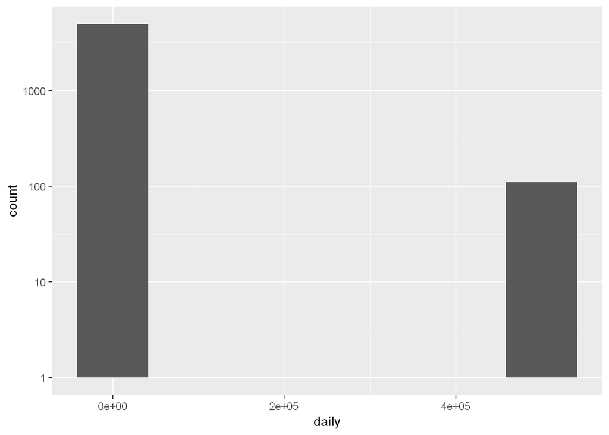

```r
#find toal rainfalls for every day
data.df %>% group_by(year, month, day) %>% mutate(daily = sum(hour_0:hour_23)) -> data.df

data.df %>% ggplot(aes(daily))+geom_histogram(bins = 7)+scale_y_log10()
```

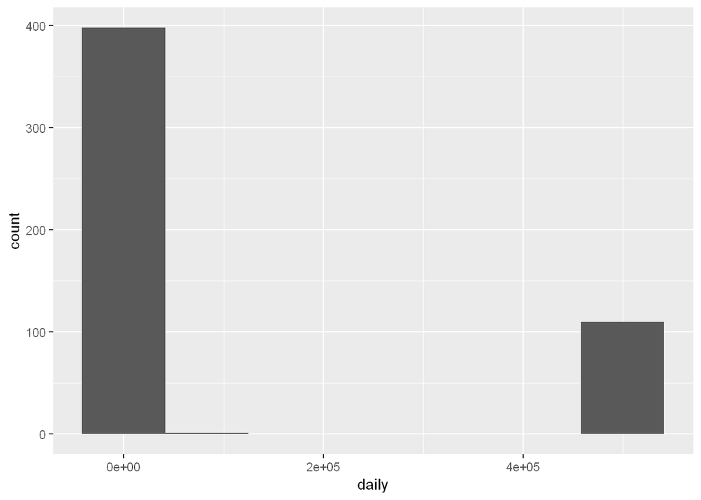

```r
fixed.df <- data.df %>% filter(daily > 0)
fixed.df %>% ggplot(aes(daily))+geom_histogram(bins = 7)
```

## Синтаксис и типизирование

- Для каждой строки кода поясните полученный результат, либо объясните почему она ошибочна.

  ```
  v <- c("4", "8", "15", "16", "23", "42")
  max(v)
  sort(v)
  sum(v)
  ```

  Переменная `v` содержит набор строк, поэтому функции `max(v)` и `sort(v)` сравнивают объекты являющиеся строками в лекискографическом порядке. Функция `sum(v)` выдаёт ошибку, т.к. для строк не задана операция сложения по-умолчанию, а конкатенация != сложение.
- Для следующих наборов команд поясните полученный результат, либо объясните почему они ошибочна.

  ```
  v2 <- c("5",7,12)
  v2[2] + v2[3]
  ```

  Одна переменная может хранить список элементов лишь одного типа => все элементы приводятся к единому типу. Строку нельзя просто так преобразовать в число, а число в строку - можно, поэтому `7` и `12` преобразуются в строки, для которых опять же не задана операция сложения по-умолчанию.

```
df3 <- data.frame(z1="5",z2=7,z3=12)
df3[1,2] + df3[1,3] #то же самое, что и 7 + 12

l4 <- list(z1="6", z2=42, z3="49", z4=126)
l4[[2]] + l4[[4]]   #сложение значений - корректная операция
l4[2] + l4[4]       #сложение колонок - ошибка
```

## Работа с функциями и операторами

- Оператор двоеточие создаёт последовательность целых чисел по порядку. Этот оператор — частный случай функции `seq()`, которую вы использовали раньше. Изучите эту функцию, вызвав команду `?seq`. Испольуя полученные знания выведите на экран:
  1. Числа от 1 до 10000 с инкрементом 372.
  2. Числа от 1 до 10000 длиной 50.

     ```
     seq(1, 10000, by = 372)
     seq(1, 10000, length.out = 50)
     ```

- Функция `rep()` повторяет переданный вектор указанное число раз. Объясните разницу между `rep(1:5,times=3)` и `rep(1:5, each=3)`.

Аргумент `times` указывает на повторение всего вектора заданное число раз, а аргумент `each` задаёт повторения каждого элемента в отдельности.

# Требования к оформлению

Работа должна быть выполнена на языке R Markdown в среде RStudio и сохранена в свой репозиторий в папку hw01. Также требуется сохранить результат в виде PDF и отправить почтой для проверки. Справку по установке и настройке R Markdown можно найти здесь http://rmarkdown.rstudio.com/